# SIMPLE CLUSTERS BASED ON WIN RATES

### SECTIONS

1. Summary
2. Method
3. Clusters verbally described
4. Clusters visually described
5. Table of aggregated values by cluster
6. Hierachical clustering on principal components
7. Clusters displayed on scatter plots
8. Variable relevance per cluster
9. Clusters over time
10. Cluster populations by college and major institutions

### 1. SUMMARY

This shows principal investigators sorted into eight clusters using only two criteria: the win rates by count of proposal and sum of funds requested.

### 2. METHOD

First, principal investigators (PI’s) with three or fewer proposals are filtered out. 1,265 principal investigators (43%) are removed and 1,672 principal investigators (57%) are kept.

Second, two variables are calculated per principal investigator:

- Rate of proposals won (count rate)
- Rate of funds requested won (sum rate)

Third, the rates are centered and scaled.

Fourth, principle components are extracted.

Fifth, hierarchical clustering using Euclidean distance and Ward’s method is used to produce eight clusters.

The clusters are named, described verbally and visually, and the cluster populations by colleges and major institutions are shown.

### 3. CLUSTERS VERBALLY DESCRIBED

**CLUSTER 1: ROCK BOTTOM**  
Principal investigators in Cluster 1 have less than ~20% win rates by both count and sum.

It has a population of 211 PIs (12.6%) and accounts for only 2.1% of total requested funds won.

**CLUSTER 2: DOMINANT**  
Principal investigators in Cluster 2 have less than ~40% win rates by both count and sum.

It has the largest share of the population and proposals submitted, as well as a large share of funds awarded.

It has a population of 370 PIs (22.1%) and accounts for 16.6% of total requested funds won.

**CLUSTER 3: BIG WHIFF**  
Principal investigators in Cluster 3 have less than ~30% win rates by sum and less than ~70% win rate by count.

They have a respectable win rate by count but lose the larger proposals.

Cluster 3 has a population of 190 PIs (11.4%) and accounts for 5.5% of total requested funds won.

**CLUSTER 4: MONEY**  
Principal investigators in Cluster 4 have less than ~60% win rates by sum and less than ~50% win rates by count.

It has the largest share of funds requested won.

Cluster 4 has a population of 245 PIs (14.7%) and accounts for 25.5% of total requested funds won.

**CLUSTER 5: MISSING THE BIG WINS**  
Principal investigators in Cluster 5 have less than ~50% win rates by sum and greater than ~50% win rates by count.

They have an excellent win rate by count but like Cluster 3, they lose the larger proposals.

**CLUSTER 6: BRONZE MEDAL**

Principal investigators in Cluster 6 have greater than ~40% win rates by sum and less than ~65% win rates by count.

Their win rates by sum are in third place behind Clusters 7 and 8. And compared to Clusters 3 and 5, they win the large proposals.

**CLUSTER 7: SILVER MEDAL**  
Principal investigators in Cluster 7 have greater than ~50% win rates by sum and greater than ~60% win rates by count. They have the second-highest win rates.

**CLUSTER 8: GOLD MEDAL**  
Principal investigators in Cluster 8 have greater than ~80% win rates by sum and greater than ~65% win rates by count. They have the highest win rates.

### 4. CLUSTERS VISUALLY DESCRIBED

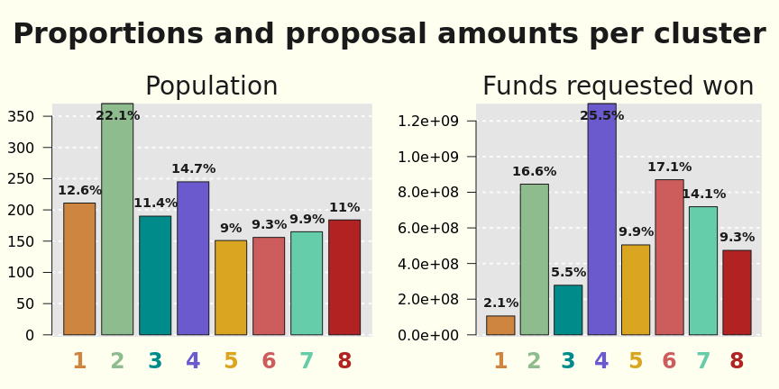

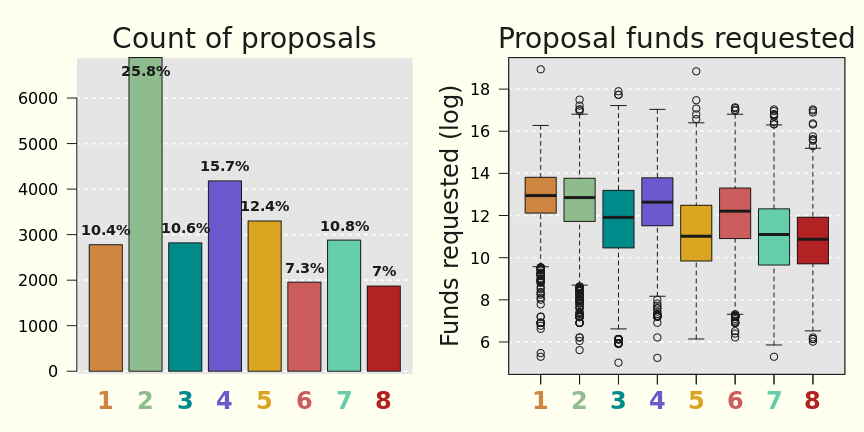

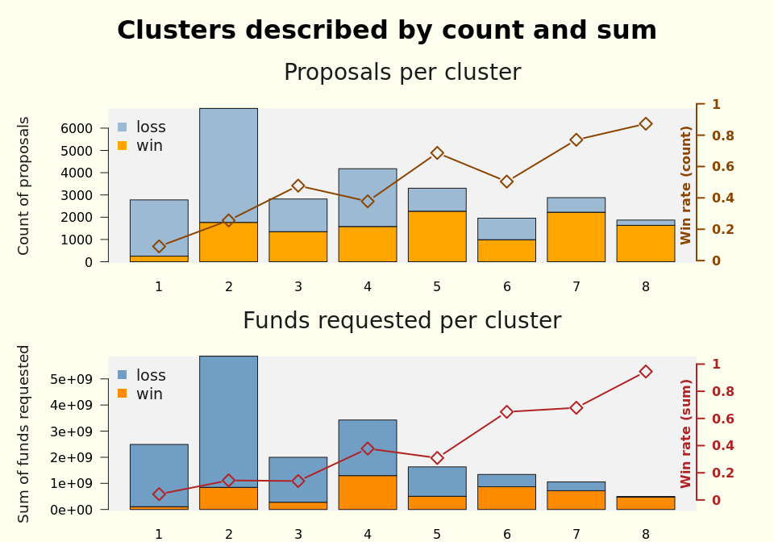

### 5. TABLE OF AGGREGATED VALUES BY CLUSTER

Aggregated Metrics by Rate Cluster

| cluster | population | pop_perc | count_total | count_perc | win.sum | sum_perc | win.count | win.mean | win.median | loss.sum | loss.count | loss.mean | loss.median | sum.rate | count.rate | color |
| --- | --- | --- | --- | --- | --- | --- | --- | --- | --- | --- | --- | --- | --- | --- | --- | --- |
| 1 | 211 | 12.6 | 2,780 | 10 | 106,000,000 | 2 | 250 | 420,000 | 152,000 | 2,384,000,000 | 2,530 | 943,500 | 422,600 | 0.04 | 0.09 | peru |
| 2 | 370 | 22.1 | 6,890 | 26 | 845,000,000 | 17 | 1,770 | 479,000 | 160,000 | 5,025,000,000 | 5,120 | 981,100 | 419,400 | 0.14 | 0.26 | darkseagreen |
| 3 | 190 | 11.4 | 2,820 | 11 | 278,000,000 | 6 | 1,350 | 206,000 | 50,000 | 1,721,000,000 | 1,470 | 1,169,100 | 412,800 | 0.14 | 0.48 | darkcyan |
| 4 | 245 | 14.7 | 4,180 | 16 | 1,297,000,000 | 26 | 1,580 | 821,000 | 250,000 | 2,130,000,000 | 2,600 | 819,400 | 360,300 | 0.38 | 0.38 | slateblue |
| 5 | 151 | 9.0 | 3,300 | 12 | 505,000,000 | 10 | 2,270 | 223,000 | 38,000 | 1,127,000,000 | 1,030 | 1,090,200 | 295,800 | 0.31 | 0.69 | goldenrod |
| 6 | 156 | 9.3 | 1,960 | 7 | 870,000,000 | 17 | 990 | 883,000 | 223,000 | 472,000,000 | 970 | 486,200 | 187,200 | 0.65 | 0.50 | indianred |
| 7 | 165 | 9.9 | 2,880 | 11 | 719,000,000 | 14 | 2,220 | 324,000 | 53,000 | 340,000,000 | 660 | 514,900 | 130,000 | 0.68 | 0.77 | mediumaquamarine |
| 8 | 184 | 11.0 | 1,870 | 7 | 474,000,000 | 9 | 1,630 | 290,000 | 55,000 | 27,000,000 | 240 | 114,300 | 38,900 | 0.95 | 0.87 | firebrick |

### 6. HIERARCHICAL CLUSTERING ON PRINCIPAL COMPONENTS

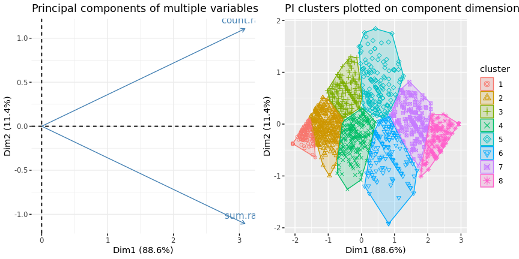

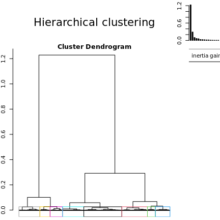

### 7. CLUSTERS DISPLAYED ON SCATTER PLOTS

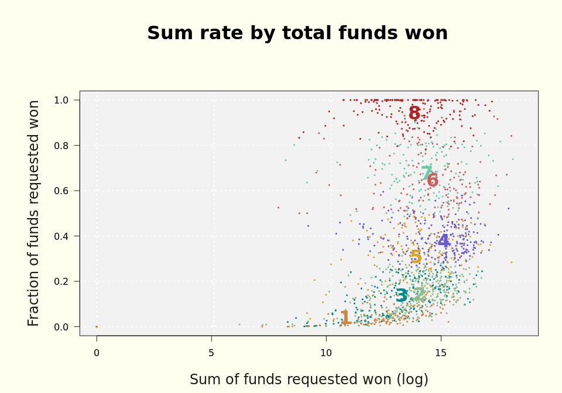

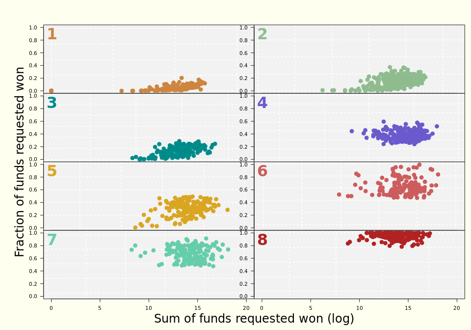

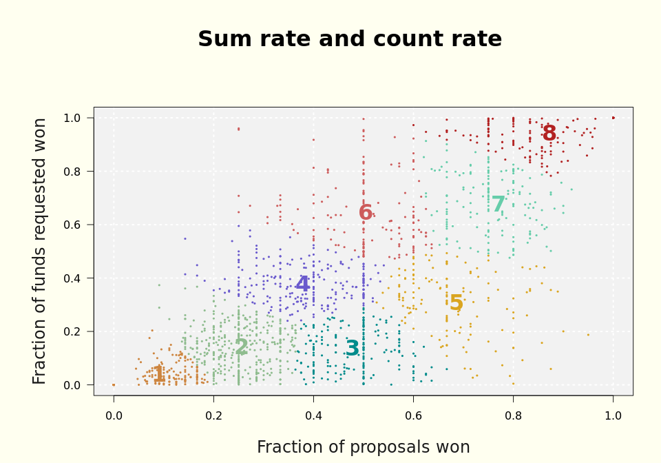

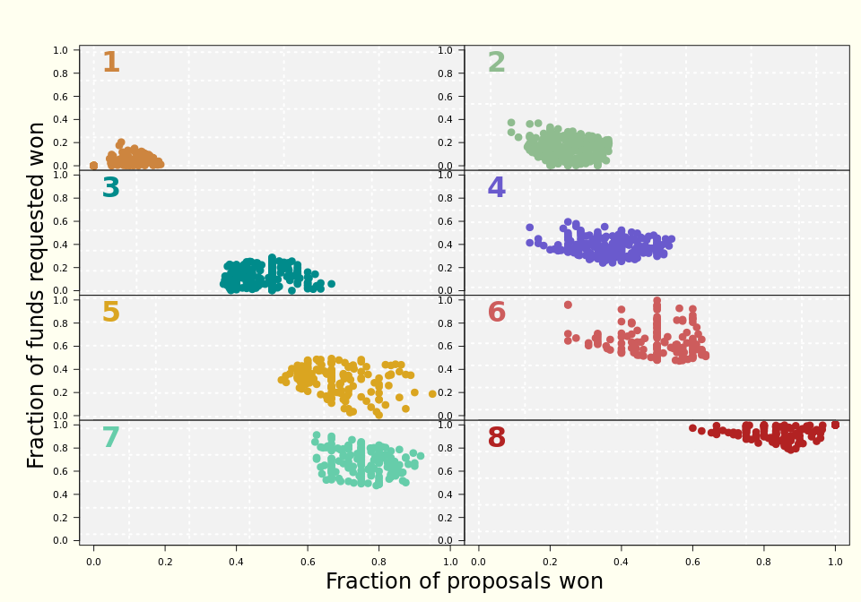

### 8. VARIABLE RELEVANCE PER CLUSTER

*This section is omitted due to the few variables used in clustering. Both variables are relevant to all clusters.*

### 9. CLUSTERS OVER TIME

Although this clustering did not include any time variables, the submission patterns by cluster are shown.

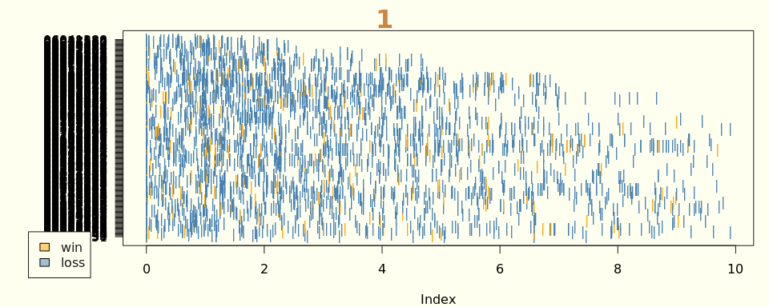

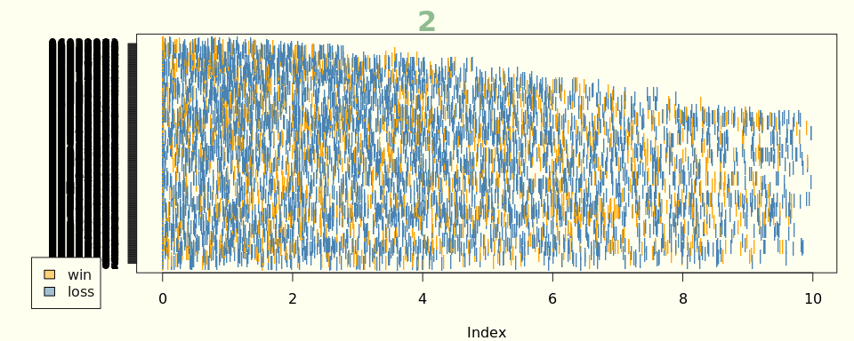

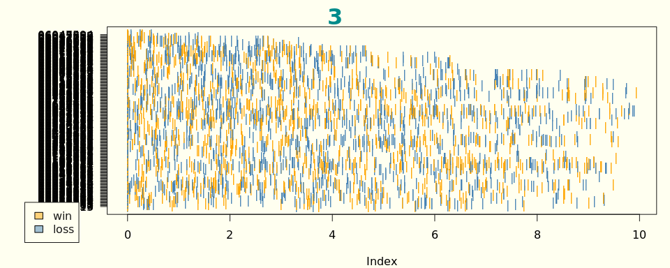

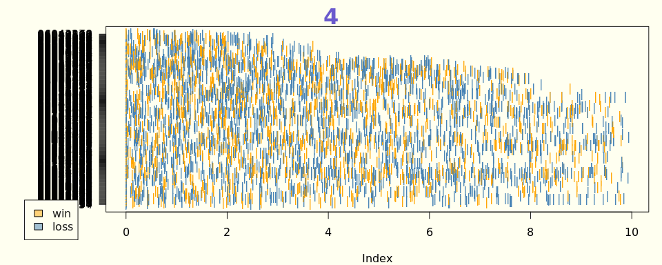

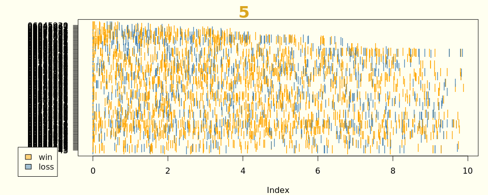

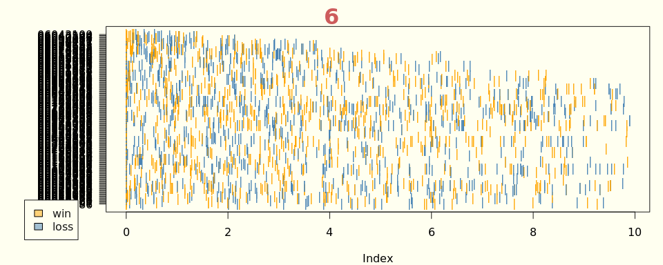

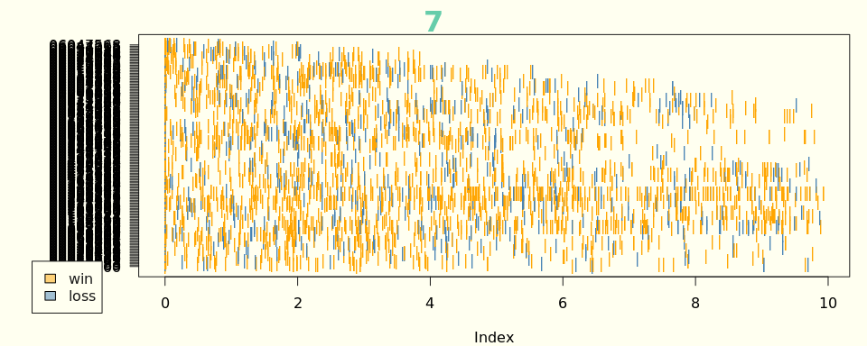

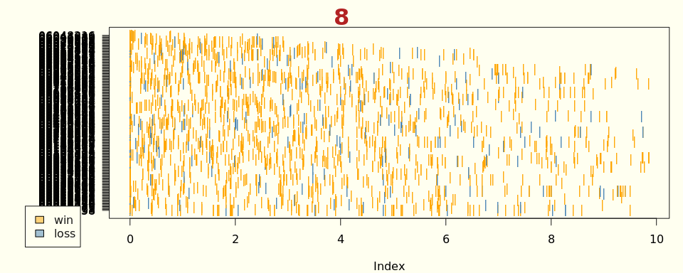

### 10. CLUSTER POPULATIONS BY COLLEGE AND MAJOR INSTITUTIONS

259 (15.5)% PI’s appear in multiple colleges or institutions.

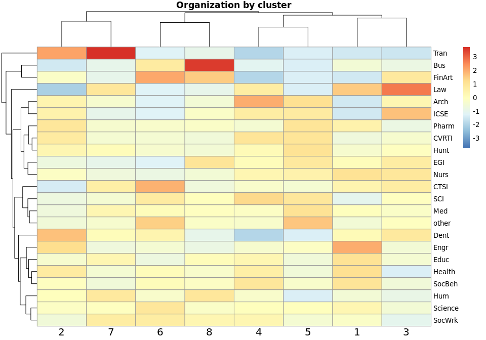

Percent of organization population per cluster

| Org | 1 | 2 | 3 | 4 | 5 | 6 | 7 | 8 |
| --- | --- | --- | --- | --- | --- | --- | --- | --- |
| Arch | 0.0 | 29.4 | 17.6 | 29.4 | 11.8 | 0.0 | 5.9 | 5.9 |
| Bus | 6.7 | 6.7 | 6.7 | 6.7 | 0.0 | 13.3 | 0.0 | 60.0 |
| CTSI | 12.5 | 8.3 | 20.8 | 12.5 | 4.2 | 20.8 | 16.7 | 4.2 |
| CVRTI | 5.6 | 33.3 | 11.1 | 22.2 | 11.1 | 5.6 | 5.6 | 5.6 |
| Dent | 11.1 | 44.4 | 22.2 | 0.0 | 0.0 | 11.1 | 11.1 | 0.0 |
| Educ | 17.2 | 20.7 | 10.3 | 17.2 | 3.4 | 3.4 | 13.8 | 13.8 |
| EGI | 10.5 | 15.8 | 21.1 | 15.8 | 10.5 | 0.0 | 0.0 | 26.3 |
| Engr | 23.0 | 39.1 | 9.8 | 11.9 | 5.5 | 5.5 | 3.4 | 1.7 |
| FinArt | 0.0 | 22.2 | 22.2 | 0.0 | 0.0 | 22.2 | 0.0 | 33.3 |
| Health | 17.9 | 33.9 | 1.8 | 19.6 | 3.6 | 8.9 | 5.4 | 8.9 |
| Hum | 6.2 | 25.0 | 6.2 | 12.5 | 0.0 | 6.2 | 18.8 | 25.0 |
| Hunt | 7.7 | 28.2 | 13.5 | 16.0 | 11.5 | 5.8 | 10.9 | 6.4 |
| ICSE | 0.0 | 30.0 | 30.0 | 20.0 | 10.0 | 0.0 | 0.0 | 10.0 |
| Law | 20.0 | 0.0 | 40.0 | 20.0 | 0.0 | 0.0 | 20.0 | 0.0 |
| Med | 10.0 | 17.3 | 12.4 | 13.7 | 11.5 | 9.0 | 13.7 | 12.3 |
| Nurs | 17.1 | 22.9 | 22.9 | 17.1 | 8.6 | 2.9 | 2.9 | 5.7 |
| other | 6.4 | 17.9 | 14.1 | 12.8 | 14.1 | 17.9 | 6.4 | 10.3 |
| Pharm | 12.9 | 35.5 | 6.5 | 11.3 | 11.3 | 6.5 | 6.5 | 9.7 |
| SCI | 2.7 | 16.2 | 13.5 | 24.3 | 10.8 | 13.5 | 5.4 | 13.5 |
| Science | 12.0 | 23.0 | 9.7 | 15.2 | 6.5 | 14.3 | 9.7 | 9.7 |
| SocBeh | 16.5 | 24.1 | 8.9 | 21.5 | 5.1 | 8.9 | 3.8 | 11.4 |
| SocWrk | 8.7 | 17.4 | 4.3 | 17.4 | 4.3 | 13.0 | 17.4 | 17.4 |
| Tran | 0.0 | 50.0 | 0.0 | 0.0 | 0.0 | 0.0 | 50.0 | 0.0 |

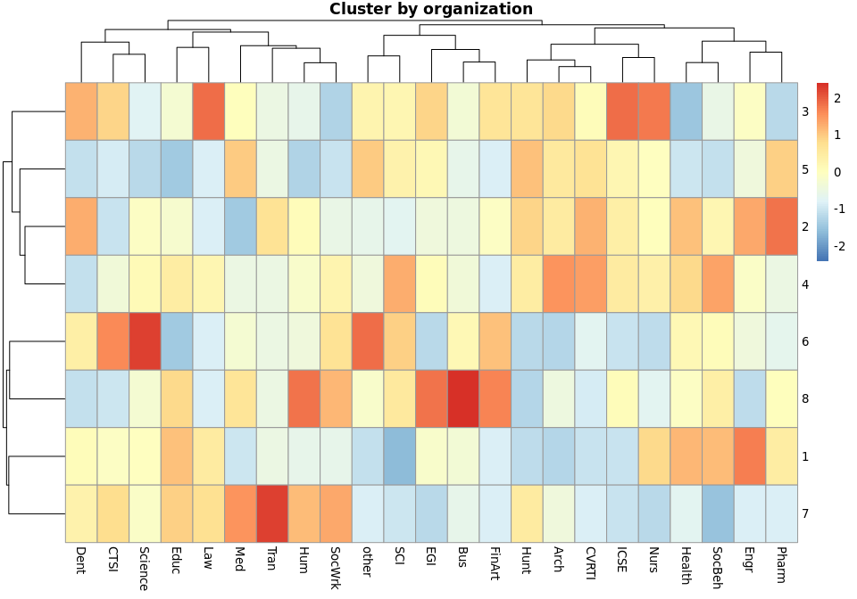

Percent of cluster population per organization

| Org | Arch | Bus | CTSI | CVRTI | Dent | Educ | EGI | Engr | FinArt | Health | Hum | Hunt | ICSE | Law | Med | Nurs | other | Pharm | SCI | Science | SocBeh | SocWrk | Tran |
| --- | --- | --- | --- | --- | --- | --- | --- | --- | --- | --- | --- | --- | --- | --- | --- | --- | --- | --- | --- | --- | --- | --- | --- |
| 1 | 0.0 | 0.4 | 1.3 | 0.4 | 0.4 | 2.2 | 0.9 | 23.5 | 0.0 | 4.3 | 0.4 | 5.2 | 0.0 | 0.4 | 33.9 | 2.6 | 2.2 | 3.5 | 0.4 | 11.3 | 5.7 | 0.9 | 0.0 |
| 2 | 1.1 | 0.2 | 0.4 | 1.3 | 0.9 | 1.3 | 0.7 | 20.4 | 0.4 | 4.2 | 0.9 | 9.8 | 0.7 | 0.0 | 30.0 | 1.8 | 3.1 | 4.9 | 1.3 | 11.1 | 4.2 | 0.9 | 0.2 |
| 3 | 1.3 | 0.4 | 2.2 | 0.9 | 0.9 | 1.3 | 1.8 | 10.1 | 0.9 | 0.4 | 0.4 | 9.3 | 1.3 | 0.9 | 42.7 | 3.5 | 4.8 | 1.8 | 2.2 | 9.3 | 3.1 | 0.4 | 0.0 |
| 4 | 1.8 | 0.4 | 1.1 | 1.4 | 0.0 | 1.8 | 1.1 | 9.9 | 0.0 | 3.9 | 0.7 | 8.8 | 0.7 | 0.4 | 37.8 | 2.1 | 3.5 | 2.5 | 3.2 | 11.7 | 6.0 | 1.4 | 0.0 |
| 5 | 1.1 | 0.0 | 0.6 | 1.1 | 0.0 | 0.6 | 1.1 | 7.4 | 0.0 | 1.1 | 0.0 | 10.2 | 0.6 | 0.0 | 51.1 | 1.7 | 6.2 | 4.0 | 2.3 | 8.0 | 2.3 | 0.6 | 0.0 |
| 6 | 0.0 | 1.1 | 2.9 | 0.6 | 0.6 | 0.6 | 0.0 | 7.4 | 1.1 | 2.9 | 0.6 | 5.1 | 0.0 | 0.0 | 40.0 | 0.6 | 8.0 | 2.3 | 2.9 | 17.7 | 4.0 | 1.7 | 0.0 |
| 7 | 0.5 | 0.0 | 2.1 | 0.5 | 0.5 | 2.1 | 0.0 | 4.2 | 0.0 | 1.6 | 1.6 | 8.9 | 0.0 | 0.5 | 56.0 | 0.5 | 2.6 | 2.1 | 1.0 | 11.0 | 1.6 | 2.1 | 0.5 |
| 8 | 0.5 | 4.5 | 0.5 | 0.5 | 0.0 | 2.0 | 2.5 | 2.0 | 1.5 | 2.5 | 2.0 | 5.0 | 0.5 | 0.0 | 48.2 | 1.0 | 4.0 | 3.0 | 2.5 | 10.6 | 4.5 | 2.0 | 0.0 |